# Challenge 7: Incorporating Multiple Inputs

Functions + Fish

Author

Amir Sepasian

```r
library(tidyverse)
fish <- read.csv(here::here("data", "BlackfootFish.csv"))
```

## Condition Index

A frequently used measurement for fish health is a condition index [(Wikipedia article)](https://en.wikipedia.org/wiki/Condition_index_in_fish). The following simple equation can be used to calculate the approximate condition index of a fish:

$$\text{condition index} = \frac{weight}{length^3} \times 100$$

**1. There are specific units required for the calculation of a condition index – length must be in centimeters and weight must be in grams. The weight data for the Blackfoot River fish were collected in grams; the length data were collected in millimeters. Transform the length data to the correct units.**

```r
fish <- fish |>
  mutate(length = length / 10)
```

**2. Collecting data of this sort can be very messy! Write a function that will replace unlikely `length` and `weight` measurements with `NA`. Your function should accept at least three inputs:**

- **a vector of measurements,**
- **the minimum reasonable value,**
- **the maximum reasonable value.**

**If a value falls outside these bounds, you should replace it with an `NA`.**

**Tip**

If you are struggling with the structure of your function, I would suggest reading the [Mutating Function](https://r4ds.hadley.nz/functions.html#mutate-functions) from R4DS.

ChatGBT Link: https://chatgpt.com/share/67324ea1-f0a0-8011-8fd5-fa37bd205e4f

```r
apply_na <- function(vect, low, high) {

  stopifnot(is.numeric(vect))
  case_when(vect < low ~ NA,
            vect > high ~NA,
            .default = vect)

}
```

**3. After consulting the [Montana Record Table](https://fwp.mt.gov/fish/anglingData/records) for the four species of trout included in these data, I have conjectured that it is unlikely to have measurements for fish below 5 cm and above 80 cm in length or below 10 g and above 4,000 g in weight. Use your function to modify the `length` and `weight` columns of the `fish` dataset based on my cutoffs.**

```r
fish <- fish |>
  mutate(length = apply_na(length, 5, 80),
         weight = apply_na(weight, 10, 4000))
```

**3. Write a function to calculate the condition index of a fish, given inputs of weight and length.**

**Warning**

Consider whether you will write a function that works with vectors (accepting vectors as inputs) or a function that works with data frames (accepting a dataset and variable names as inputs)!

```r
cond_index <- function(length, weight){

  return((weight / length^3) * 100)

}
```

**4. Make a thoughtful visualization of how fish conditions have varied over the duration of this study.**

**To be thoughtful…**

… you need to use at least a third variable!

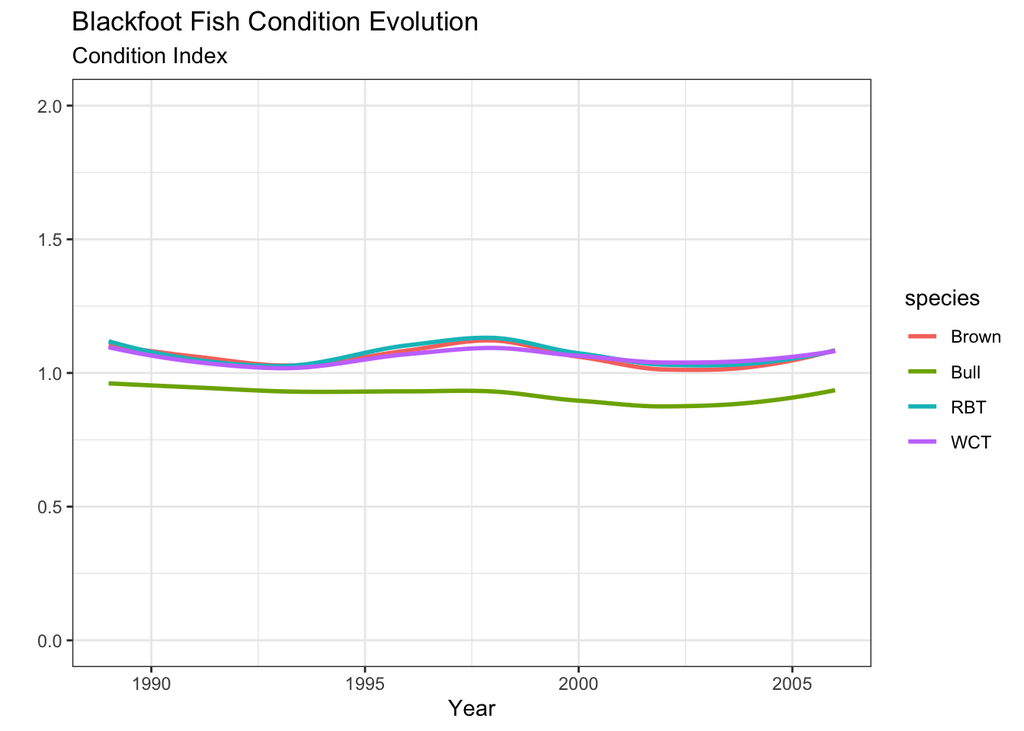

```r
fish |>
  mutate(cond_index = cond_index(length, weight)) |>
  group_by(year, species) |>
  summarize(avg_cond = mean(cond_index, na.rm = TRUE), .groups = 'drop') |>
  ggplot(aes(x = year,
             y = avg_cond,
             color = species)) +
  geom_smooth(se = FALSE) +
  labs(x = 'Year',
       y = '',
       title = 'Blackfoot Fish Condition Evolution',
       subtitle = 'Condition Index',
       color = 'species') +
  scale_y_continuous(limits = c(0, 2)) +
  theme_bw()
```